# EA20200820 Report

Robin B. Trayler

August, 21, 2020

The $\delta^{13}C$ and $\delta^{15}N$ values and elemental carbon and nitrogen contents of all samples were measured using a **Costech 4010** Elemental Analyzer coupled with a **Delta V Plus Continuous Flow Isotope Ratio Mass Spectrometer** housed in the Stable Isotope Facility at the University of California, Merced.

This report includes several files:

1. A `.html` or `.pdf` report summarizing all data corrections and instrument reproducibility
2. A `.csv` file with the corrected data
3. A `.csv` file with the uncorrected data
4. A `.Rmd` (R Markdown) document containing the **R** code used to correct the data

If you would like the original Isodat 3.0 `.dxf` files please request by sending an email to stableisotopes@ucmerced.edu

# Setup

## File Path

```r
# file path to the isodat csv file
file_path <- '~/Box Sync/Data Repository/EA/EA20200820.csv'
```

## Analysis Parameters

### Select Sample Peaks

```r
# Which peak is the N2 analyte?
nitrogen_peak <- 3
# Which peak is the CO2 analyte?
carbon_peak <- 4
# How many total peaks should there be?
total_peaks <- 2
```

### Set Rejection Criteria

```r
# rejection criteria
small_peaks <- 500 # warn about peaks smaller with an amplitude smaller than this
# should 2 sigma outlier standards be dropped from isotope corrections
drop_outliers <- TRUE
```

### Select Correction Standards

```r
# standards used in run
standards_used = c('USGS 41a', 'USGS 40')
# material to use for linearity corrections
linearity_material = c('costech acetanilide')
# material to use for drift corrections
drift_material = c('costech acetanilide')
# material to use for weight calculations
weight_percent_material = c('USGS 40', 'USGS 41a', 'costech acetanilide')
# in house 'check' materials for run quality
check_material = c('EA sed', 'MB squid', 'peach')
```

## Drift and Linearity Model Specification

### Instrument Drift

```r
# should a drift correction be applied to nitrogen
nitrogen_drift <- TRUE
# model choices are either 'lm' for linear or 'loess' for loess
nitrogen_drift_model <- 'lm'

# should a drift correction be applied to carbon
carbon_drift <- TRUE
# model choices are either 'lm' for linear or 'loess' for loess
carbon_drift_model <- 'lm'
```

### Mass Linearity

```r
# should a linearity correction be applied?
# mass linearity corrections use a linear model
nitrogen_linearity <- TRUE
carbon_linearity <- TRUE
```

# Data Screening

## Check for Missing Peaks

Sample(s) with an Identifier 1 of **NA** have fewer peaks than expected. Please check the raw data.

## Check for Small Peaks

Sample(s) with an Identifier 1 of **6248** have a mass 28 (nitrogen) amplitude smaller than **500** mV. Data from these samples may be unreliable.

Sample(s) with an Identifier 1 of **6262, 6289, 6293** have a mass 44 (carbon) amplitude smaller than **500** mV. Data from these samples may be unreliable.

# Drift Correction

## Nitrogen Drift Correction

Nitrogen isotope compositional drift over the period of analysis was monitored using the **costech acetanilide** reference material(s). Since a drift correction was requested, A **linear** model was subtracted from the raw data.

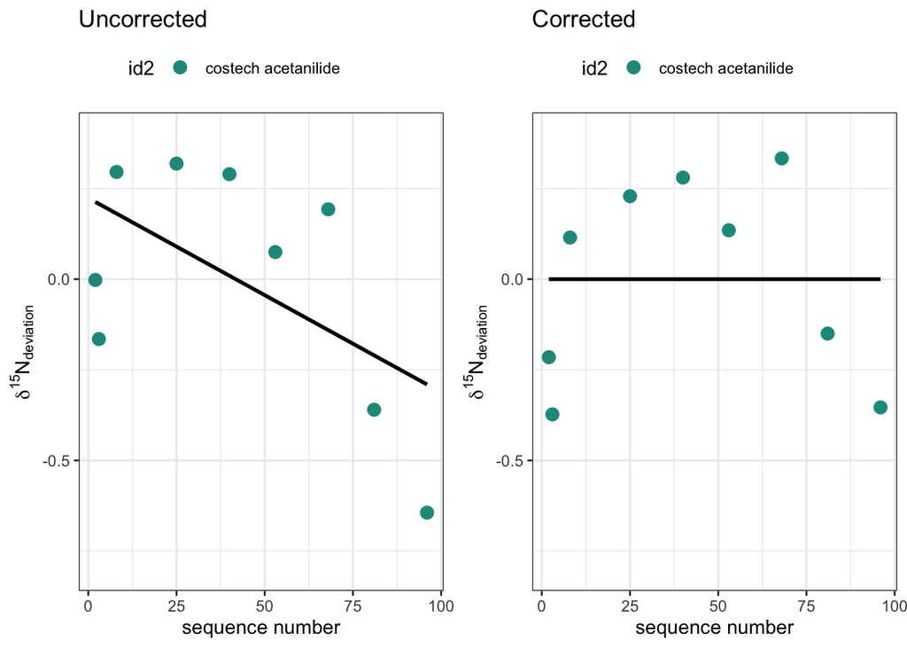

## Carbon Drift Correction

Carbon isotope compositional drift over the period of analysis was monitored using the **costech acetanilide** reference material(s). Since a drift correction was requested, A **linear** model was subtracted from the raw data.

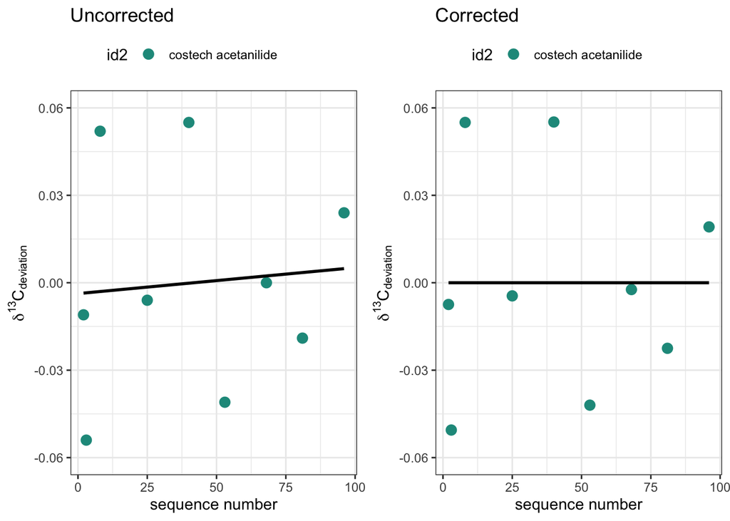

# Linearity Corrections

## Nitrogen Linearity Correction

Mass linearity of nitrogen isotope compositions was monitored using the **costech acetanilide** reference material(s). Since a linearity correction was requested, A linear trend with an $r^2$ of **0.01** was subtracted from the raw data.

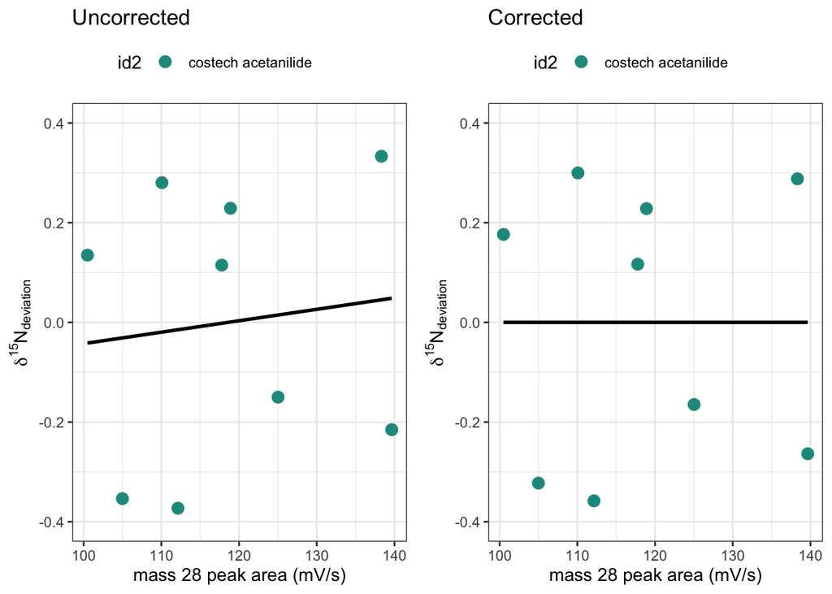

## Carbon Linearity Correction

Mass linearity of carbon isotope compositions was monitored using the **costech acetanilide** reference material(s). Since a linearity correction was requested, A linear trend with an $r^2$ of **0** was subtracted from the raw data.

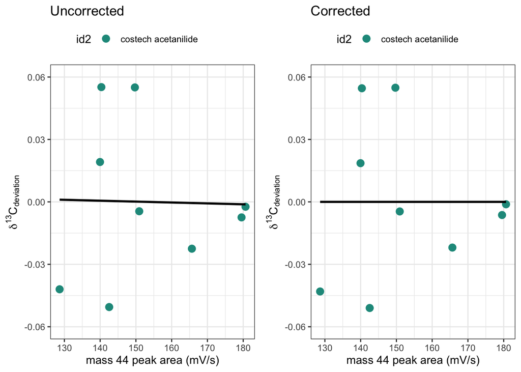

# Standardization

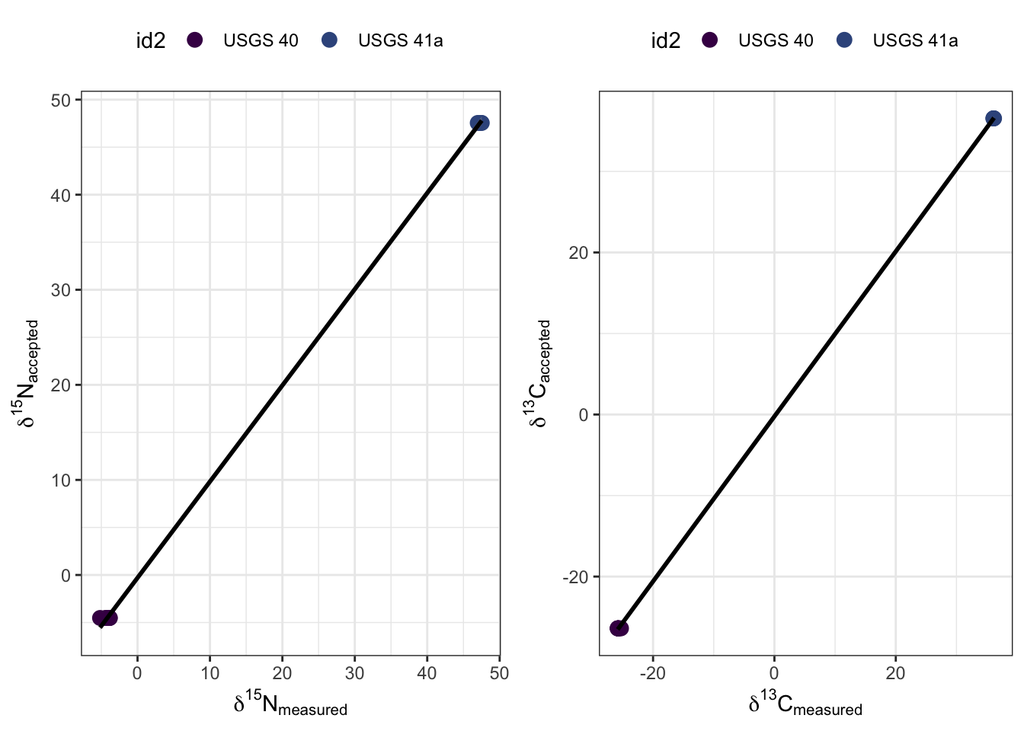

The isotope composition of unknowns samples were corrected to the international PDB ($\delta^{13}C$) and Air ($\delta^{15}N$) scales using the **USGS 41a and USGS 40** standard reference materials. Isotope compositions for standard reference materials are shown in the **Table 1**.

Table 1: Certified isotope compositions for standard reference materials

| standard | $\delta^{13}C$ | $\delta^{15}N$ |
| --- | --- | --- |
| USGS 40 | -26.39 | -4.52 |
| USGS 41a | 36.55 | 47.55 |

# Elemental Content

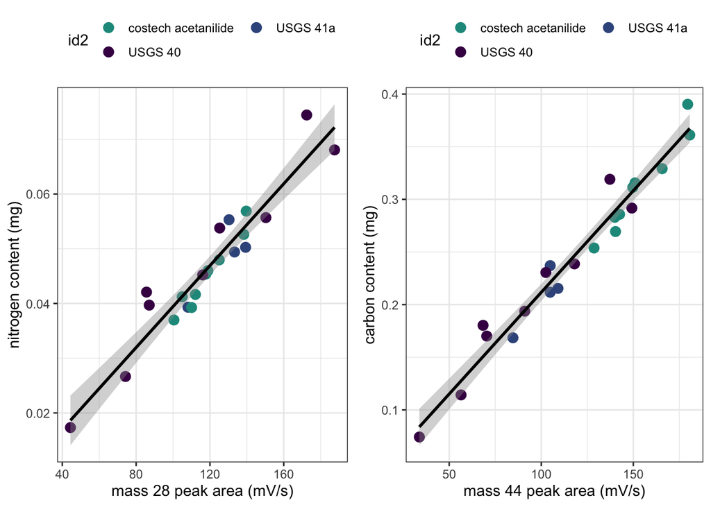

Total carbon and nitrogen contents were calculated using the **USGS 40 and USGS 41a and costech acetanilide** reference materials. Certified carbon and nitrogen contents for these reference materials are shown in the **Table 2**.

Table 2: Certified elemental contents for standard reference materials

| standard | $C \%$ | $N \%$ |
| --- | --- | --- |
| USGS 40 | 40.80 | 9.52 |
| USGS 41a | 40.80 | 9.52 |
| costech acetanilide | 71.09 | 10.36 |

# Final Data

## Summary

Summary statistics for standard reference materials and in house reference materials.

| sample | $\delta^{15}N_{mean}$ | $\delta^{15}N_{sd}$ | $\delta^{13}C_{mean}$ | $\delta^{13}C_{sd}$ | $N \%_{mean}$ | $N \%_{sd}$ | $C \%_{mean}$ | $C \%_{sd}$ | n |
| --- | --- | --- | --- | --- | --- | --- | --- | --- | --- |
| costech acetanilide | -0.34 | 0.28 | -28.45 | 0.04 | 10.65 | 0.44 | 72.09 | 2.91 | 9 |
| MB squid | 11.64 | 0.39 | -18.66 | 0.07 | 12.14 | 0.50 | 46.39 | 2.24 | 5 |
| USGS 40 | -4.65 | 0.43 | -26.34 | 0.18 | 9.30 | 1.03 | 40.36 | 4.19 | 9 |
| USGS 41a | 47.55 | 0.25 | 36.55 | 0.05 | 9.82 | 0.73 | 42.02 | 2.72 | 4 |

## Full Data Table

Corrected isotope compositions, total carbon and nitrogen content, and C/N ratios. C/N ratios are reported as wt/wt.

| Identfier 1 | sample | amount (mg) | area 28 | area 44 | $\delta^{13}C$ | $\delta^{15}N$ | $N \%$ | $C \%$ | $C \ /N$ |
| --- | --- | --- | --- | --- | --- | --- | --- | --- | --- |
| 6305 | 19290 T1 | 0.315 | 82.714 | 42.949 | -14.393 | 9.795 | 10.466 | 32.225 | 3.079 |
| 6269 | 19320 T1 | 0.226 | 33.544 | 17.568 | -12.910 | 8.773 | 6.449 | 23.232 | 3.603 |
| 6275 | 19320 T2 | 0.373 | 71.017 | 35.830 | -12.053 | 9.668 | 7.666 | 23.529 | 3.069 |
| 6270 | 19320 T4 | 0.214 | 49.074 | 27.445 | -14.256 | 9.644 | 9.525 | 33.446 | 3.511 |
| 6278 | 19320 T4 | 0.255 | 29.376 | 14.675 | -12.897 | 7.950 | 5.104 | 18.400 | 3.605 |
| 6276 | 19320 T5 | 0.368 | 74.338 | 38.782 | -13.302 | 9.817 | 8.107 | 25.397 | 3.133 |
| 6289 | 19325 T4 | 0.312 | 21.898 | 10.535 | -13.632 | 8.228 | 3.275 | 12.476 | 3.810 |
| 6290 | 19325 T5 | 0.328 | 28.283 | 13.114 | -13.422 | 9.049 | 3.843 | 13.386 | 3.483 |
| 6281 | 19327 T1 | 0.218 | 55.456 | 28.270 | -14.151 | 12.048 | 10.446 | 33.563 | 3.213 |
| 6285 | 19327 T2 | 0.276 | 81.827 | 42.762 | -14.508 | 12.956 | 11.825 | 36.647 | 3.099 |
| 6282 | 19327 T3 | 0.264 | 53.293 | 28.133 | -14.470 | 11.406 | 8.319 | 27.615 | 3.319 |
| 6318 | 19331 T1 | 0.276 | 37.238 | 16.537 | -13.000 | 10.998 | 5.781 | 18.302 | 3.166 |
| 6322 | 19331 T1 | 0.258 | 35.782 | 17.453 | -13.145 | 10.554 | 5.973 | 20.265 | 3.393 |
| 6323 | 19331 T3 | 0.378 | 35.780 | 15.490 | -13.118 | 10.802 | 4.077 | 12.829 | 3.147 |
| 6319 | 19331 T4 | 0.371 | 59.723 | 29.612 | -13.038 | 10.812 | 6.568 | 20.420 | 3.109 |
| 6296 | 19333 T1 | 0.326 | 76.843 | 38.865 | -13.912 | 11.700 | 9.439 | 28.719 | 3.042 |
| 6294 | 19333 T2 | 0.230 | 86.530 | 44.456 | -14.420 | 11.742 | 14.955 | 45.399 | 3.036 |
| 6291 | 19333 T3 | 0.271 | 26.772 | 12.653 | -14.085 | 10.255 | 4.443 | 15.873 | 3.573 |
| 6299 | 19333 T4 | 0.215 | 73.604 | 38.240 | -14.735 | 11.769 | 13.749 | 42.984 | 3.126 |
| 6303 | 19334 T1 | 0.258 | 101.719 | 57.606 | -15.452 | 11.907 | 15.534 | 50.313 | 3.239 |
| 6309 | 19334 T2 | 0.340 | 97.224 | 51.168 | -14.792 | 11.715 | 11.293 | 34.522 | 3.057 |
| 6306 | 19334 T3 | 0.244 | 102.098 | 53.169 | -15.008 | 12.626 | 16.484 | 49.688 | 3.014 |
| 6293 | 19335 T1 | 0.258 | 20.360 | 9.531 | -12.989 | 9.770 | 3.737 | 14.336 | 3.836 |
| 6292 | 19335 T2 | 0.314 | 60.390 | 31.446 | -13.702 | 12.160 | 7.840 | 25.255 | 3.221 |
| 6308 | 19335 T3 | 0.262 | 46.760 | 24.037 | -13.786 | 12.330 | 7.450 | 24.807 | 3.330 |
| 6265 | 19337 T1 | 0.205 | 66.029 | 39.559 | -14.562 | 9.405 | 13.037 | 46.323 | 3.553 |
| 6266 | 19337 T2 | 0.262 | 47.227 | 26.562 | -13.641 | 8.390 | 7.516 | 26.668 | 3.548 |
| 6268 | 19337 T3 | 0.252 | 45.940 | 22.352 | -13.095 | 8.307 | 7.623 | 24.501 | 3.214 |
| 6271 | 19337 T4 | 0.226 | 30.852 | 15.333 | -13.427 | 7.496 | 6.003 | 21.323 | 3.552 |
| 6277 | 19337 T5 | 0.268 | 114.306 | 57.453 | -13.476 | 10.255 | 16.712 | 48.325 | 2.892 |

[output cut: 64 more lines]